## Chick weights

The `ChickWeight` data set is part of the base package `datasets`. See `?ChickWeight` for details on the data. For all of the questions use `dplyr` functions with the pipe `%>%` whenever possible.

**Submission instructions**: Create a folder named `ds202_hw4`, and name the RMarkDown file including your solutions `hw4.Rmd` under this folder. For the submission, create a GitHub repository named `ds202_hw4` under your GitHub account, and push both `hw4.Rmd` and the knitted `hw4.html` before the deadline. I will assume you use the same GitHub username as for your HW3 submission. The latest version of your homework appearing on GitHub before the deadline is graded. *It is crucial to follow the exact folder structure and file names*. This homework is **due on March 4** before class.

1. Get a frequency breakdown of the number of chicks, their average weight and the standard deviation of the weights in each of the diets at the start of the study. Store the resulting data frame in a variable named `weight0` and print.

   ```r
   #   head(cw, 30)
   weight0 = cw %>%
         filter(Time == 0) %>%
         group_by(Diet) %>%
         summarize(Average=mean(weight), Deviation=sd(weight))

   print(weight0)
   ```

   ```
   ## # A tibble: 4 x 3
   ##   Diet  Average Deviation
   ##   <fct>   <dbl>     <dbl>
   ## 1 1        41.4     0.995
   ## 2 2        40.7     1.49
   ## 3 3        40.8     1.03
   ## 4 4        41       1.05
   ```

2. Each chick should have twelve weight measurements. Use the `dplyr` package to identify how many measurements are there for each chick. Extract a subset of the data for all chicks with complete information, name the data set `complete`, and print the first 3 rows. (Hint: you might want to use mutate to introduce a helper variable consisting of the number of observations)

   ```r
   complete = cw %>%
          group_by(Chick) %>%
          mutate(observation.count=length(weight)) %>%
          filter(observation.count == 12)

   complete %>% head(3)
   ```

   ```
   ## # A tibble: 3 x 5
   ## # Groups:   Chick [1]
   ##   weight  Time Chick Diet  observation.count
   ##    <dbl> <dbl> <ord> <fct>             <int>
   ## 1     42     0 1     1                    12
   ## 2     51     2 1     1                    12
   ## 3     59     4 1     1                    12
   ```

3. In the complete data set introduce a new variable that measures the current weight difference compared to day 0. Name this variable `weightgain` and print the first 3 rows of the new data frame.

   ```r
   weight_init = cw %>% filter(Time == 0) %>% arrange(Chick)
   cw = cw %>%
        mutate(weightgain = weight - weight_init[Chick, "weight"])

   head(cw, 3)
   ```

   ```
   ##   weight Time Chick Diet weightgain
   ## 1     42    0     1    1          0
   ## 2     51    2     1    1          9
   ## 3     59    4     1    1         17
   ```

4. Use `{ggplot2}` to create side-by-side boxplots of `weightgain` by `Diet` for day 21. Change the order of the categories in the Diet variable such that the boxplots are ordered by median `weightgain`, and the lower limit of the y axis should be 0. Describe the relationship in 2-3 sentences.

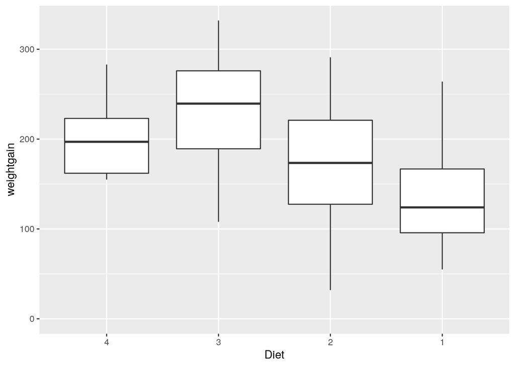

   ```r
   medians = cw %>% group_by(Diet) %>% summarize(median = median(weightgain)) %>% arrange(desc(median))

   #   print(medians)
   #   print(levels(factor(c(medians["Diet"]))))
   #   diets = ordered(cw$Diet, levels=c(medians["Diet"]))
   #   print(diets)

   #   cw$Diet = reorder(cw$Diet, levels(factor(c(medians["Diet"]))))

   cw %>%
   filter(Time == 21) %>% mutate(Diet = factor(Diet, levels=c(medians$Diet))) %>%
   #   mutate(weightmedian = medians[Diet, "median"]$median) %>%
   #   arrange(weightmedian, Chick) %>%
   ggplot(aes(x=Diet, y=weightgain)) + geom_boxplot() + ylim(0, NA)
   ```

   From looking at this data, I can conclude a couple of things. The weight gain of the chicks seems to increase in a direct correlation with the number of the diet that they are on, except for 4. The diet with the highest weight gain is diet 3. Diets one and four seem to have lagging distributions, while diets two and three seem to have pretty normal distributions.
5. Answer each of the following questions using numerical and graphical summary. Also explain what you found: (a) Which chick gained the most weight and which gained the least weight? (b) What diets were they on?

   **Part a:**

   To see which chicks have the most extreme weights we can simply call the corresponding methods for each:

   ```r
   mx = max(cw$weightgain)
   mn = min(cw$weightgain)

   print(cat("Max weight gain is:", mx, fill=TRUE))
   ```

   ```
   ## Max weight gain is: 332
   ## NULL
   ```

   ```r
   print(cat("Min weight gain is:", mn, fill=TRUE))
   ```

   ```
   ## Min weight gain is: -4
   ## NULL
   ```

   As we can see here, the chick that gained the most weight gained 332, and the chick that gained the least amount of weight, actually lost 4. To see which chicks they are, we can use `select`

   ```r
   extremes = cw %>% filter(weightgain == mx | weightgain == mn)
   print(extremes)
   ```

   ```
   ##   weight Time Chick Diet weightgain
   ## 1     39    2     3    1         -4
   ## 2     35    2    18    1         -4
   ## 3    373   21    35    3        332
   ```

   And now we can see that the chicks that lost weight are chicks 3, and 18, and the chick that gained the most weight is chick 35.

   **Part b:**

   For the analysis for this part I’ll refer you to my solution for *Part a* above. The diets are as follows, the two chicks that lost weight were on diet 1, and the chick that gained the most weight was on diet 3.

   And because you asked for a graphic

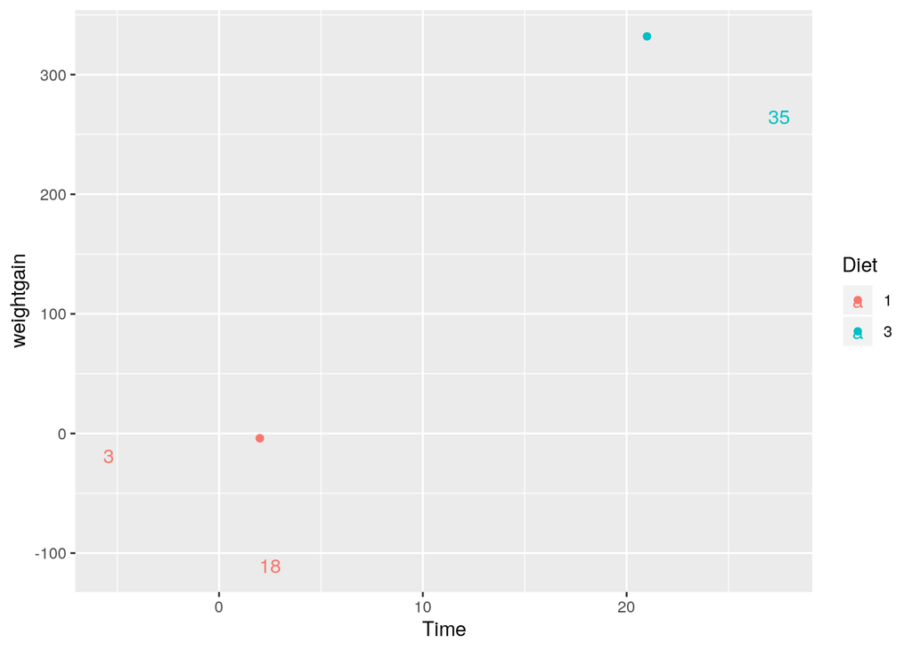

   ```r
   ggplot(extremes, aes(x=Time, y=weightgain, color=Diet, label=Chick)) + geom_point() + geom_text(position='jitter', width=0.1, height=0.1)
   ```

6. For the chicks with the least and the most weight at time 0, plot their growth trajectories over time.

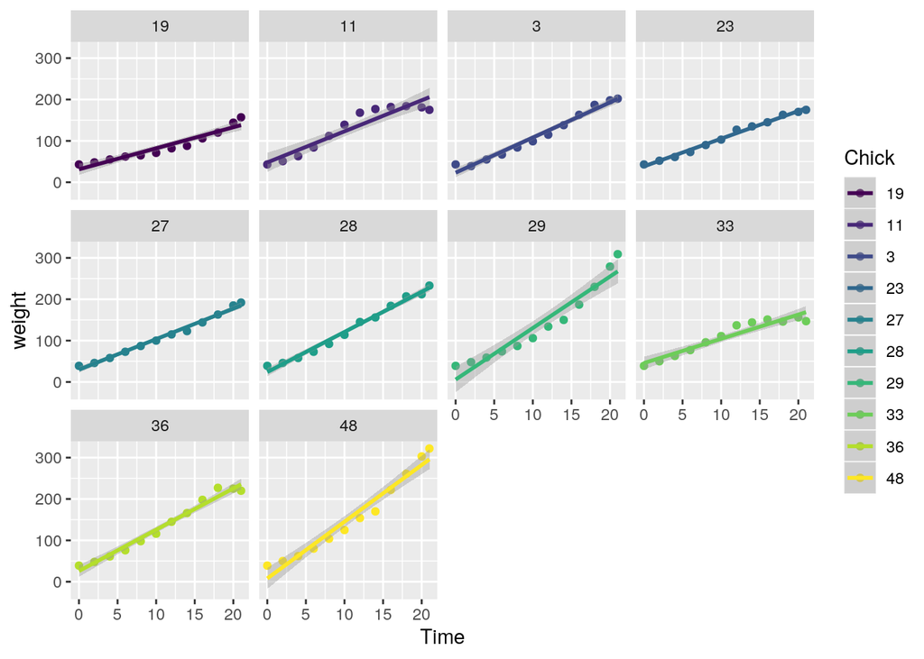

   ```r
   mx = max(weight_init$weight)
   mn = min(weight_init$weight)

   extremes = weight_init %>% filter((weight == mx | weight == mn) & (Chick %in% complete$Chick))

   chicks = unique(extremes$Chick)

   gextremes = cw %>% filter(Chick %in% chicks) %>% arrange(Chick) %>% mutate(weight0 = weight_init$weight[Chick], filtered_chicks = Chick) # group_by(Chick) %>% arrange(Chick)
   #   print(gextremes)

   ggplot(gextremes, aes(x=Time, y=weight, color=Chick)) + geom_point() + facet_wrap(~filtered_chicks) + geom_smooth(method='lm')
   ```

   ```r
   #   i = 1
   #   repeat {
   #
   #       chick = chicks[i]
   #       extremes = cw %>% filter(Chick == chick)
   #       plot = plot + stat_smooth(data=extremes, method='lm', aes(x=Time, y=weight, color=Chick), se=F)
   #
   #       i = i + 1
   #       if(i > length(chicks)) { break }
   #   }
   ```

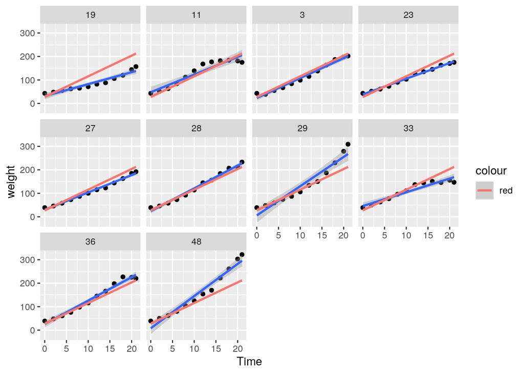

   ```r
   #   ggplot(gextremes, aes(x=Time, y=weight, color=Chick)) + geom_point() + stat_smooth(data=cw, method='lm', aes(x=Time, y=weight), se=F) + facet_wrap(~Chick) + stat_smooth(method='lm', se=F)
   ggplot(gextremes, aes(x=Time, y=weight)) + geom_point() + geom_smooth(method='lm') + facet_wrap(~filtered_chicks) + geom_smooth(data=cw, aes(x = Time, y = weight, color="red"), method="lm")
   ```

   ```r
   #   plot = plot + stat_smooth(data=cw, method='lm', aes(x=Time, y=weight), se=F)

   #   plot
   ```

8. What else do you find interesting in the dataset? Show your exploratory analysis.

   An interesting question that could be asked is, “Is there a correlation between incomplete data sets, and which diet the chick was eating?” Assuming that an incomplete data line most likely means that the chick died during the experiment, it raises a good question of whether maybe the diet had something to do with it.

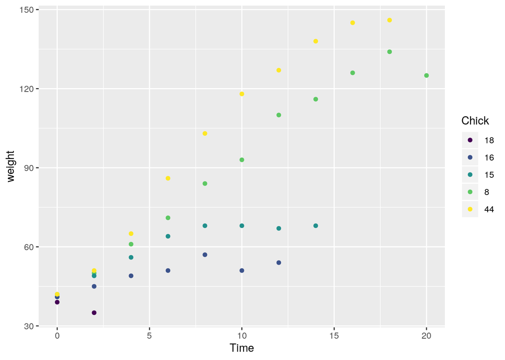

   ```r
   incomplete = cw %>% filter(!(Chick %in% complete$Chick)) %>% group_by(Diet)
   ggplot(incomplete, aes(x=Time, y=weight, color=Chick)) + geom_point()
   ```

   After looking at how many chicks don’t have complete data, I’m going to guess that this might be a bit of a bad sample, but lets continue anyway; With a bar chart, I can easily see the percentage in each diet.

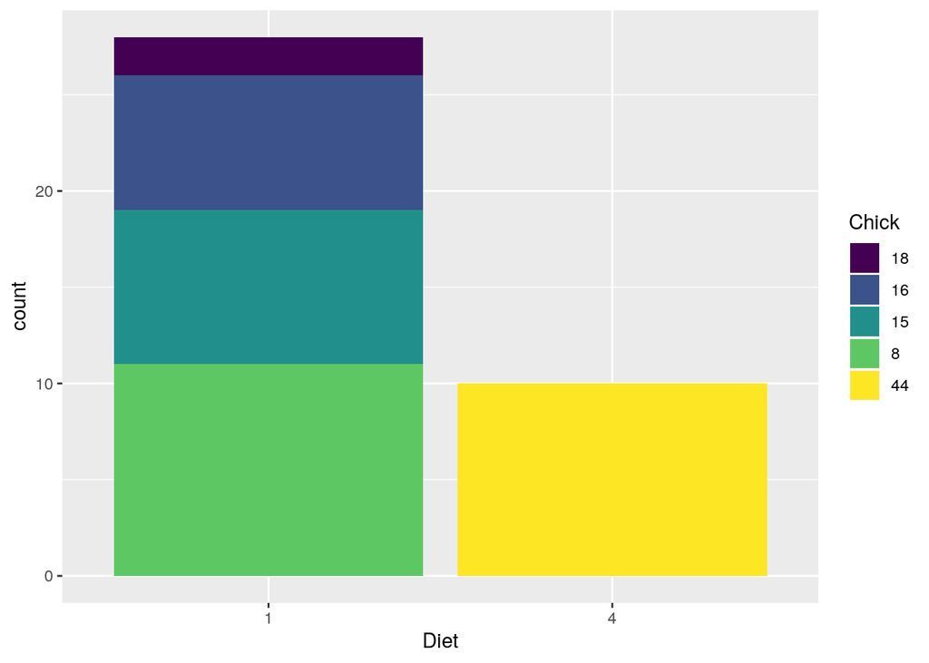

   ```r
   ggplot(incomplete, aes(x=Diet, fill=Chick)) + geom_bar()
   ```

   From this graph, you can see that roughly 80% of the chicks that didn’t have complete data entries, were from diet 1, and only one entry was from diet 4, that’s actually kind of suspicious, but could have several reasons.
   - Diet 1 kills the chicks more often than any other diet (the obvious one)
   - The experiment was a linear process meaning that most mistakes would be made early one during initial stages (diet 1)
   - The experimenters hadn’t dealt with chicks before and thus might have killed a few in the beginning from negligence
   - It was just a bad batch of chicks
   - It was an illness

   But one other thing to notice here is that three of the chicks are almost completely consecutive, which points to an illness, spreading amongst nearby chicks in the containment area. In fact I’d be confident to say that whatever caused chicks 18, 16, and 15, to not complete their entries was likely the same thing, whether that be a mistake made a by a person, an illness, maybe an animal, who knows.

   This was really cool, I didn’t expect to find anything when I looked for the absence of information instead of presence of information.

Note: your submission is supposed to be fully reproducible, i.e. the TA and I will ‘knit’ your submission in RStudio.